# Predicting Barbell-Lift Execution from Wearable Sensors

Author: Sonja Sahebzad

15 September 2026

# Executive summary

This report predicts the five exercise-execution classes (`classe`) from accelerometers worn on the belt, forearm, arm, and dumbbell. A random forest was selected because the sensor relationships are nonlinear and may interact. Model choice was checked against a single classification tree. Five-fold cross-validation on a development set estimated random-forest accuracy at **99.32%**; an untouched validation set produced **99.61%** accuracy and **0.39%** error. The final model predicts the 20 quiz cases as shown below.

# Data and preprocessing

The training data contain 19622 observations. The outcome has five levels: A denotes the correct lift; B–E denote four distinct errors. I removed row identifiers, participant names, timestamps, and window bookkeeping fields. These fields describe data collection rather than body movement and could let a model memorize participants or recording order. I also removed variables observed in fewer than 95% of rows. This left 52 complete sensor predictors and avoided imputing columns that are almost entirely missing.

```r
training_raw <- read.csv("pml-training.csv",
  na.strings = c("NA", "#DIV/0!", ""), check.names = FALSE)
metadata <- c("X", "user_name", "raw_timestamp_part_1",
  "raw_timestamp_part_2", "cvtd_timestamp", "new_window", "num_window")
candidate <- setdiff(names(training_raw), c(metadata, "classe", ""))
predictors <- candidate[vapply(training_raw[candidate],
  function(x) mean(!is.na(x)), numeric(1)) >= 0.95]
model_data <- training_raw[c(predictors, "classe")]
model_data$classe <- factor(model_data$classe)
```

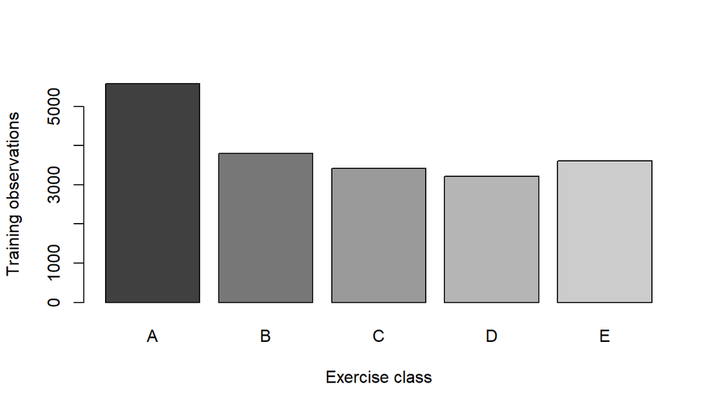

Figure 1. Exercise classes are reasonably represented, supporting stratified resampling.

# Validation design and candidate models

I used a fixed seed and stratified the observations by `classe`, assigning 75% to development and 25% (4907 rows) to final validation. All model comparison occurred within the development set. Five stratified folds provided out-of-sample predictions for every development observation. This separation prevents the final validation result from benefiting from model selection.

The candidates were (1) a classification tree, which is easy to interpret but unstable, and (2) a random forest, which averages many decorrelated trees. The forest used `mtry = floor(sqrt(52))`, a conventional classification default. The cross-validation comparison strongly favored the forest.

```r
for (k in 1:5) {
  rf <- randomForest(classe ~ ., data = development[fold != k, ],
    ntree = 250, mtry = floor(sqrt(length(predictors))))
  rf_prediction <- predict(rf, development[fold == k, ])
  cv_accuracy[k] <- mean(rf_prediction == development$classe[fold == k])
}
```

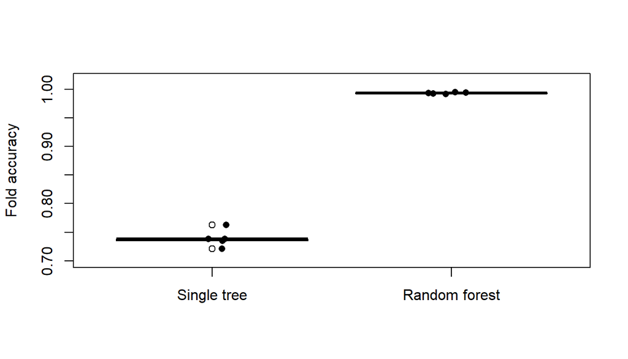

Figure 2. Five-fold cross-validation accuracy by candidate model.

The forest’s mean cross-validation accuracy was 0.9932 (fold SD 0.0012), versus 0.7390 (SD 0.0148) for the single tree. Thus the substantive conclusion is sensitive to choosing a sufficiently flexible model, but the forest result itself is stable across folds.

# Final validation and expected error

After selection, I refit both candidates on the complete development set and evaluated them once on the held-out validation set. The random forest achieved 0.9961 accuracy, compared with 0.7281 for the single tree.

Held-out confusion matrix for the selected random forest

|  | A | B | C | D | E |
| --- | --- | --- | --- | --- | --- |
| A | 1392 | 2 | 0 | 0 | 1 |
| B | 1 | 947 | 2 | 0 | 0 |
| C | 0 | 5 | 850 | 1 | 0 |
| D | 0 | 0 | 4 | 799 | 1 |
| E | 0 | 0 | 0 | 2 | 900 |

The held-out error estimate is **0.39%**. A 95% Wilson interval places the underlying accuracy between 99.40% and 99.75%, equivalent to an error interval from 0.25% to 0.60%. Five-fold cross-validation implies 0.68% error, while the final forest’s out-of-bag estimate is 0.27%. These independent estimates all indicate an expected out-of-sample error below 1%, although performance on new people could be lower because the random split includes measurements from the same six participants in both sets.

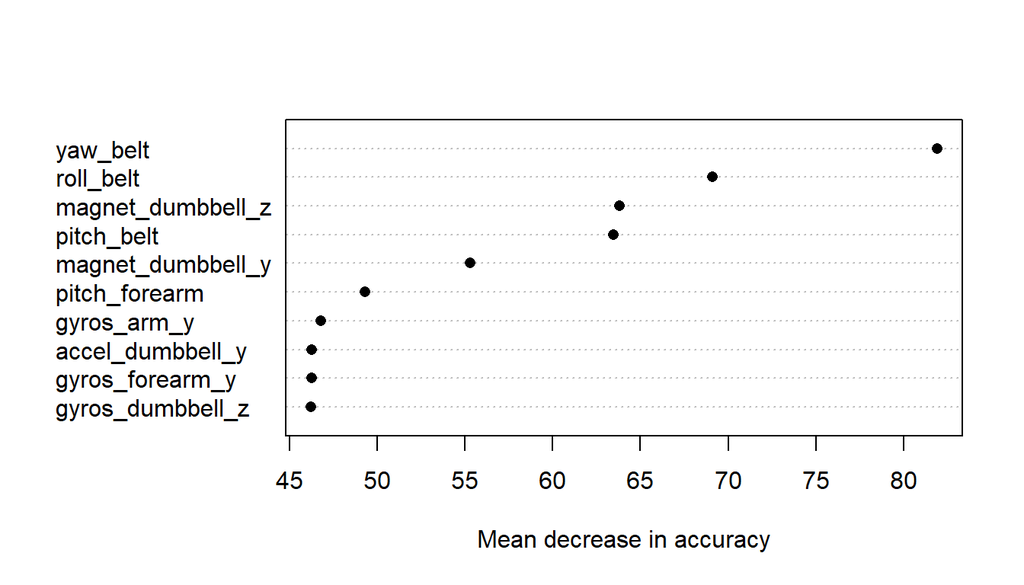

Figure 3. Ten most influential predictors in the final forest.

No manual interaction terms were added. A forest already models interactions through successive splits—for example, a forearm orientation threshold can lead to different rules depending on belt acceleration. Enumerating pairwise terms for 52 inputs would add 1,326 candidates and make a linear expansion difficult to validate. The strong, consistent resampling performance supports the automatic treatment, while the weaker single tree confirms that one simple partition is insufficient.

# Discussion

The selected random forest was refit to all 19622 labeled rows with 750 trees. The following are the requested predictions, ordered by `problem_id`.

| Problem ID | Predicted classe |
| --- | --- |
| 1 | B |
| 2 | A |
| 3 | B |
| 4 | A |
| 5 | A |
| 6 | E |
| 7 | D |
| 8 | B |
| 9 | A |
| 10 | A |
| 11 | B |
| 12 | C |
| 13 | B |
| 14 | A |
| 15 | E |
| 16 | E |
| 17 | A |
| 18 | B |
| 19 | B |
| 20 | B |

# Conclusion

The data were provided by the Pontifical Catholic University of Rio de Janeiro’s [Weight Lifting Exercise Dataset](http://web.archive.org/web/20161224072740/http:/groupware.les.inf.puc-rio.br/har). The course copies of the [training data](https://d396qusza40orc.cloudfront.net/predmachlearn/pml-training.csv) and [20 test cases](https://d396qusza40orc.cloudfront.net/predmachlearn/pml-testing.csv) are retained unchanged.